# Bellabeat: Health Product Data Analysis in R

Beatrice Costanza Marrano

11 January 2022

## Case Study: How Can a Wellness Technology Company Play It Smart?

**1. A clear summary of the business task (ASK)**

Bellabeat is a high-tech company that manufactures health-focused smart products for women to empower them with knowledge about their own health and habits. The aim of this company is to analyze smart device usage data in order to gain insight into how people are already using their smart devices and then use this information to optimize its marketing strategy. Business questions:

- What are some trends in smart device usage?
- How could these trends apply to Bellabeat costumers?
- How could these trends help influence Bellabeat marketing strategy?

**2. A description of all data sources used (PREPARE)**

- The data is located in a Kaggle dataset called “FitBit Fitness Tracker Data” which is of public domain so we can freely use it.
- It is organized by daily activity, weight and sleep and it is in a long format.
- There aren’t any issues with bias or credibility. In addition, the data are ROCCC which stands for reliable, original, comprehensive, current and cited.
- Data integrity is verified since all the files have consistent columns with the right type of data.
- One limit of the FitBit dataset is that it is from 2016 so maybe it isn’t exactly representative of the present trends and in addition, while Bellabeat is designed for women, it is for everyone.

*Sort and filter the data:*

For this analysis I will focus on understanding the trend in smart device usage. Especially, I will analyze the daily activity, the weight and the sleep habits by using RStudio.

Packages loading and importing libraries:

```r
#install required packages
#install.packages("tidyverse")
#install.packages("skimr")
#install.packages("dplyr")
#install.packages("ggplot2")

#install required libraries:
library(tidyverse)
library(skimr)
library(dplyr)
library(ggplot2)


#set as working directory the one that contains the data in order to simplify calls to data
setwd("/Users/mac/Desktop/GOOGLE CERTIFICATE/Case study 2/bellabeat data" )
```

Importing the datasets:

```r
#importing the data
daily_activity <- read.csv("dailyActivity_merged.csv")
sleep_day <- read.csv("sleepDay_merged.csv")
weight_log <- read.csv("weightLogInfo_merged.csv")

#summary of the datasets
skim_without_charts(daily_activity)
```

Data summary

| Name | daily_activity |
| --- | --- |
| Number of rows | 940 |
| Number of columns | 15 |
| _______________________ |  |
| Column type frequency: |  |
| character | 1 |
| numeric | 14 |
| ________________________ |  |
| Group variables | None |

**Variable type: character**

| skim_variable | n_missing | complete_rate | min | max | empty | n_unique | whitespace |
| --- | --- | --- | --- | --- | --- | --- | --- |
| ActivityDate | 0 | 1 | 8 | 9 | 0 | 31 | 0 |

**Variable type: numeric**

| skim_variable | n_missing | complete_rate | mean | sd | p0 | p25 | p50 | p75 | p100 |
| --- | --- | --- | --- | --- | --- | --- | --- | --- | --- |
| Id | 0 | 1 | 4.855407e+09 | 2.424805e+09 | 1503960366 | 2.320127e+09 | 4.445115e+09 | 6.962181e+09 | 8.877689e+09 |
| TotalSteps | 0 | 1 | 7.637910e+03 | 5.087150e+03 | 0 | 3.789750e+03 | 7.405500e+03 | 1.072700e+04 | 3.601900e+04 |
| TotalDistance | 0 | 1 | 5.490000e+00 | 3.920000e+00 | 0 | 2.620000e+00 | 5.240000e+00 | 7.710000e+00 | 2.803000e+01 |
| TrackerDistance | 0 | 1 | 5.480000e+00 | 3.910000e+00 | 0 | 2.620000e+00 | 5.240000e+00 | 7.710000e+00 | 2.803000e+01 |
| LoggedActivitiesDistance | 0 | 1 | 1.100000e-01 | 6.200000e-01 | 0 | 0.000000e+00 | 0.000000e+00 | 0.000000e+00 | 4.940000e+00 |
| VeryActiveDistance | 0 | 1 | 1.500000e+00 | 2.660000e+00 | 0 | 0.000000e+00 | 2.100000e-01 | 2.050000e+00 | 2.192000e+01 |
| ModeratelyActiveDistance | 0 | 1 | 5.700000e-01 | 8.800000e-01 | 0 | 0.000000e+00 | 2.400000e-01 | 8.000000e-01 | 6.480000e+00 |
| LightActiveDistance | 0 | 1 | 3.340000e+00 | 2.040000e+00 | 0 | 1.950000e+00 | 3.360000e+00 | 4.780000e+00 | 1.071000e+01 |
| SedentaryActiveDistance | 0 | 1 | 0.000000e+00 | 1.000000e-02 | 0 | 0.000000e+00 | 0.000000e+00 | 0.000000e+00 | 1.100000e-01 |
| VeryActiveMinutes | 0 | 1 | 2.116000e+01 | 3.284000e+01 | 0 | 0.000000e+00 | 4.000000e+00 | 3.200000e+01 | 2.100000e+02 |
| FairlyActiveMinutes | 0 | 1 | 1.356000e+01 | 1.999000e+01 | 0 | 0.000000e+00 | 6.000000e+00 | 1.900000e+01 | 1.430000e+02 |
| LightlyActiveMinutes | 0 | 1 | 1.928100e+02 | 1.091700e+02 | 0 | 1.270000e+02 | 1.990000e+02 | 2.640000e+02 | 5.180000e+02 |
| SedentaryMinutes | 0 | 1 | 9.912100e+02 | 3.012700e+02 | 0 | 7.297500e+02 | 1.057500e+03 | 1.229500e+03 | 1.440000e+03 |
| Calories | 0 | 1 | 2.303610e+03 | 7.181700e+02 | 0 | 1.828500e+03 | 2.134000e+03 | 2.793250e+03 | 4.900000e+03 |

```r
skim_without_charts(sleep_day)
```

Data summary

| Name | sleep_day |
| --- | --- |
| Number of rows | 413 |
| Number of columns | 5 |
| _______________________ |  |
| Column type frequency: |  |
| character | 1 |
| numeric | 4 |
| ________________________ |  |
| Group variables | None |

**Variable type: character**

| skim_variable | n_missing | complete_rate | min | max | empty | n_unique | whitespace |
| --- | --- | --- | --- | --- | --- | --- | --- |
| SleepDay | 0 | 1 | 20 | 21 | 0 | 31 | 0 |

**Variable type: numeric**

| skim_variable | n_missing | complete_rate | mean | sd | p0 | p25 | p50 | p75 | p100 |
| --- | --- | --- | --- | --- | --- | --- | --- | --- | --- |
| Id | 0 | 1 | 5.000979e+09 | 2.06036e+09 | 1503960366 | 3977333714 | 4702921684 | 6962181067 | 8792009665 |
| TotalSleepRecords | 0 | 1 | 1.120000e+00 | 3.50000e-01 | 1 | 1 | 1 | 1 | 3 |
| TotalMinutesAsleep | 0 | 1 | 4.194700e+02 | 1.18340e+02 | 58 | 361 | 433 | 490 | 796 |
| TotalTimeInBed | 0 | 1 | 4.586400e+02 | 1.27100e+02 | 61 | 403 | 463 | 526 | 961 |

```r
skim_without_charts(weight_log)
```

Data summary

| Name | weight_log |
| --- | --- |
| Number of rows | 67 |
| Number of columns | 8 |
| _______________________ |  |
| Column type frequency: |  |
| character | 2 |
| numeric | 6 |
| ________________________ |  |
| Group variables | None |

**Variable type: character**

| skim_variable | n_missing | complete_rate | min | max | empty | n_unique | whitespace |
| --- | --- | --- | --- | --- | --- | --- | --- |
| Date | 0 | 1 | 19 | 21 | 0 | 56 | 0 |
| IsManualReport | 0 | 1 | 4 | 5 | 0 | 2 | 0 |

**Variable type: numeric**

| skim_variable | n_missing | complete_rate | mean | sd | p0 | p25 | p50 | p75 | p100 |
| --- | --- | --- | --- | --- | --- | --- | --- | --- | --- |
| Id | 0 | 1.00 | 7.009282e+09 | 1.950322e+09 | 1.503960e+09 | 6.962181e+09 | 6.962181e+09 | 8.877689e+09 | 8.877689e+09 |
| WeightKg | 0 | 1.00 | 7.204000e+01 | 1.392000e+01 | 5.260000e+01 | 6.140000e+01 | 6.250000e+01 | 8.505000e+01 | 1.335000e+02 |
| WeightPounds | 0 | 1.00 | 1.588100e+02 | 3.070000e+01 | 1.159600e+02 | 1.353600e+02 | 1.377900e+02 | 1.875000e+02 | 2.943200e+02 |
| Fat | 65 | 0.03 | 2.350000e+01 | 2.120000e+00 | 2.200000e+01 | 2.275000e+01 | 2.350000e+01 | 2.425000e+01 | 2.500000e+01 |
| BMI | 0 | 1.00 | 2.519000e+01 | 3.070000e+00 | 2.145000e+01 | 2.396000e+01 | 2.439000e+01 | 2.556000e+01 | 4.754000e+01 |
| LogId | 0 | 1.00 | 1.461772e+12 | 7.829948e+08 | 1.460444e+12 | 1.461079e+12 | 1.461802e+12 | 1.462375e+12 | 1.463098e+12 |

We can notice that the weight_log dataset contains less observations because not all the users had uploaded their weight. For this reason we will keep this dataset separate from the others.

Instead, we want to merge the 2 datasets daily_acitvity and sleep_day with 2 columns in common (Id and Date). In order to do that, we need to rename the date column name so that it is the same in both datasets. In addition, it is also important to check if there are any spaces and/or differences in the cells of the two datasets in order to eliminate them and make them fit together.

```r
daily_activity <- rename(daily_activity, Date= ActivityDate)
sleep_day <- rename(sleep_day, Date= SleepDay)
sleep_day$Date<-gsub("12:00:00 AM","",as.character(sleep_day$Date))
sleep_day$Date<-gsub(" ","",as.character(sleep_day$Date))
```

Merging the daily_activity and sleep_day datasets by 2 common columns (Id and Date):

```r
combined_sleep_daily_activity <- merge(sleep_day, daily_activity,by=c("Id", "Date"))
```

So we will now work with combined_sleep_daily_activity and weight_log datasets.

**3. Documentation of any cleaning or manipulation of data (PROCESS)**

Before analyzing these datasets, I will add some new attributes that will help me working more effectively.

*Daily activity and sleep*

```r
#adding a new attribute: percentage of time passed in bed sleeping
combined_sleep_daily_activity <- combined_sleep_daily_activity %>% mutate( SleepingMinutesInBed= TotalMinutesAsleep/TotalTimeInBed *100)
```

I will group the users into 5 different categories based on the number of steps they do each day:

- Sedentary: if the steps are less than 5000
- Low Active: if the steps are more than 5000 and less than 7500
- Somewhat Active: if the steps are more than 7500 and less than 10000
- Active: if the steps are more than 10000 and less than 12500
- Highly Active: if the steps are more than 12500

```r
#adding a new attribute: user type activity
combined_sleep_daily_activity <- combined_sleep_daily_activity %>%
  mutate(UserType_activity = factor(case_when( TotalSteps <5000 ~ "Sedentary",
                                        TotalSteps >=5000 & TotalSteps <7500 ~ "Low Active",
                                        TotalSteps >=7500 & TotalSteps <10000 ~ "Somewhat Active",
                                        TotalSteps >=10000 & TotalSteps <12500~ "Active",
                                        TotalSteps >=12500 ~ "Highly Active"),levels=c("Sedentary", "Low Active", "Somewhat Active", "Active", "Highly Active")))
```

I will group the users into 3 different categories based on the number of total minutes asleep:

- Under sleep: if the minutes asleep are less than 420
- Normal sleep: if the minutes asleep are more than 420 and less than 480
- Over sleep: if the minutes asleep are more than 480

```r
#adding a new attribute: user type sleep
combined_sleep_daily_activity <- combined_sleep_daily_activity %>%
  mutate(UserType_sleep = factor(case_when(TotalMinutesAsleep < 420 ~ "Under sleep",
                                    TotalMinutesAsleep >= 420 & TotalMinutesAsleep <= 480 ~ "Normal sleep",
                                    TotalMinutesAsleep > 480 ~ "Over sleep"), levels=c("Under sleep", "Normal sleep", "Over sleep")))
```

*Weight*

I will group the users into 4 different categories based on the BMI level:

- Underweight: if the BMI is less than 18.5
- Healthy weight: if the BMI is more than 18.5 and less than 25
- Overweight: if the BMI is more than 25 and less than 30
- Obese: if the BMI is more than 30

```r
#adding a new attribute: user type BMI level
weight_log <- weight_log%>%
  mutate(UserType_BMI = factor (case_when(BMI < 18.5 ~ "Underweight",
                                  BMI >= 18.5 & BMI < 25 ~ "Healthy weight",
                                  BMI >= 25 & BMI < 30 ~ "Overweight",
                                  BMI >=30 ~ "Obese"), levels=c("Underweight", "Healthy weight", "Overweight", "Obese")))
```

**4. A summary of your analysis (ANALYSE)**

Statistical summaries:

*Daily activity and sleep*

```r
combined_sleep_daily_activity %>%
  select(TotalSteps,
            Calories,
            TotalDistance,
            TotalMinutesAsleep,
            SleepingMinutesInBed,
            SedentaryMinutes) %>%
  summary()
```

```
##    TotalSteps       Calories    TotalDistance    TotalMinutesAsleep
##  Min.   :   17   Min.   : 257   Min.   : 0.010   Min.   : 58.0
##  1st Qu.: 5206   1st Qu.:1850   1st Qu.: 3.600   1st Qu.:361.0
##  Median : 8925   Median :2220   Median : 6.290   Median :433.0
##  Mean   : 8541   Mean   :2398   Mean   : 6.039   Mean   :419.5
##  3rd Qu.:11393   3rd Qu.:2926   3rd Qu.: 8.030   3rd Qu.:490.0
##  Max.   :22770   Max.   :4900   Max.   :17.540   Max.   :796.0
##  SleepingMinutesInBed SedentaryMinutes
##  Min.   : 49.84       Min.   :   0.0
##  1st Qu.: 91.22       1st Qu.: 631.0
##  Median : 94.31       Median : 717.0
##  Mean   : 91.68       Mean   : 712.2
##  3rd Qu.: 96.07       3rd Qu.: 783.0
##  Max.   :100.00       Max.   :1265.0
```

*Weight*

```r
weight_log %>%
  select(WeightKg,
         BMI) %>%
  summary()
```

```
##     WeightKg           BMI
##  Min.   : 52.60   Min.   :21.45
##  1st Qu.: 61.40   1st Qu.:23.96
##  Median : 62.50   Median :24.39
##  Mean   : 72.04   Mean   :25.19
##  3rd Qu.: 85.05   3rd Qu.:25.56
##  Max.   :133.50   Max.   :47.54
```

Key findings:

- Average steps taken is 8541.1404358
- Average number of calories burned is 2397.5738499
- Average of total distance in miles is 6.0386199

These are good numbers to stay somewhat active and in good health.

- Average minutes asleep is 419.4673123, which is a little bit under the normal sleep time and its percentage of the total time in bed is 91.6769207%
- Average weight is 72.0358214
- Average BMI is 25.1852238

**5. Supporting visualizations and key findings (SHARE)**

Creating visualizations

```r
#creating my personalized theme for visualizations
mytheme <- theme(plot.title = element_text(family = "Helvetica", face = "bold", size = (15)),
                      legend.title = element_text(colour = "black",  face = "bold.italic", family = "Helvetica"),
                      legend.text = element_text(face = "italic", colour="black",family = "Helvetica"),
                      axis.title = element_text(family = "Helvetica", size = (10), colour = "black"),
                      axis.text = element_text(family = "Courier", colour = "black", size = (10)))
```

*Plot TotalSteps vs. Calories:*

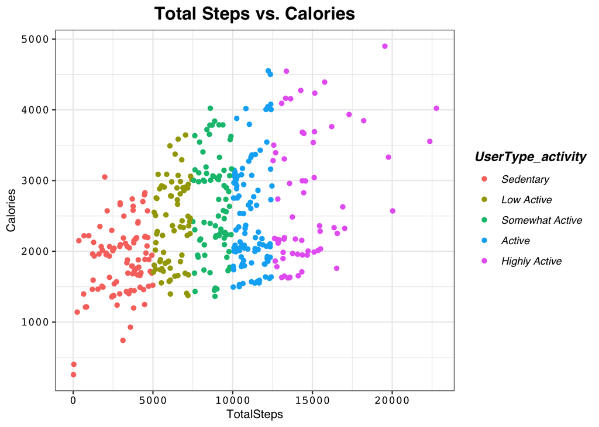

```r
#Viz 1
ggplot(data= combined_sleep_daily_activity, aes(x=TotalSteps, y = Calories, color= UserType_activity))+ geom_point() + ggtitle("Total Steps vs. Calories") + theme_bw() +mytheme +theme(plot.title = element_text(hjust = 0.5))
```

*Plot TotalMinutesAsleep and TotalTimeInBed:*

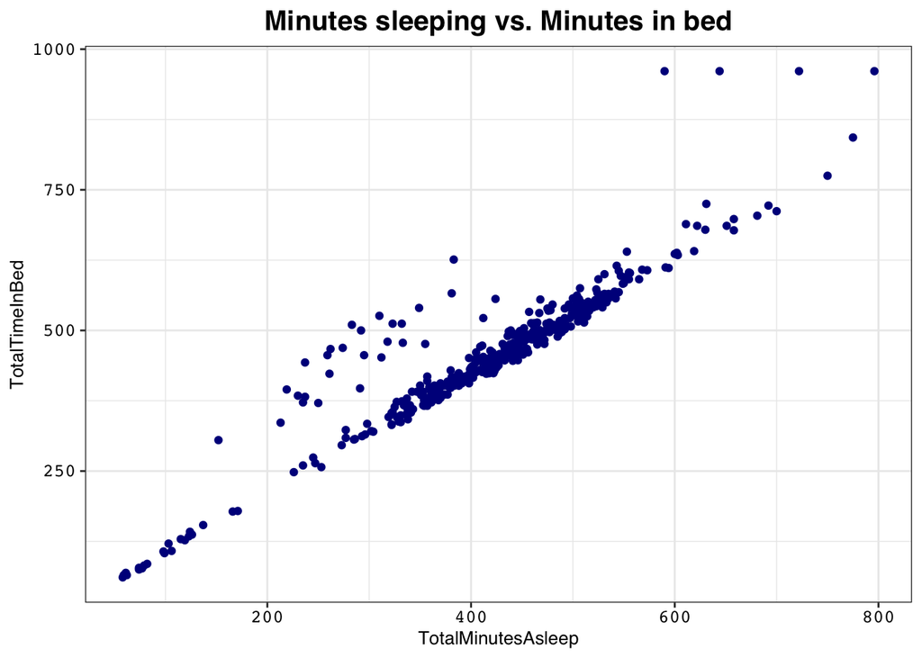

```r
#Viz 2
ggplot(data=combined_sleep_daily_activity, aes(x=TotalMinutesAsleep, y=TotalTimeInBed)) + geom_point(color='darkblue') + ggtitle("Minutes sleeping vs. Minutes in bed") + theme_bw() +mytheme +theme(plot.title = element_text(hjust = 0.5))
```

There is a linear relation between TotalMinutesAsleep and TotalTimeInBed.

*Plot Calories burned by user type:*

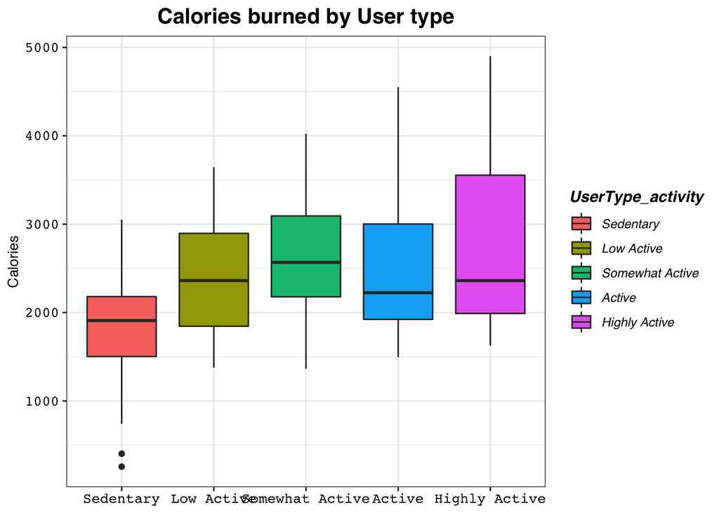

```r
#Viz 3
ggplot(combined_sleep_daily_activity, aes(UserType_activity, Calories, fill=UserType_activity)) +
  geom_boxplot() +
  theme(legend.position="none") +
  labs(title="Calories burned by User type", x=NULL) +
  theme(legend.position="none", text = element_text(size = 20),plot.title = element_text(hjust = 0.5)) + theme_bw() + mytheme +theme(plot.title = element_text(hjust = 0.5))
```

*Plot TotalSteps by user type:*

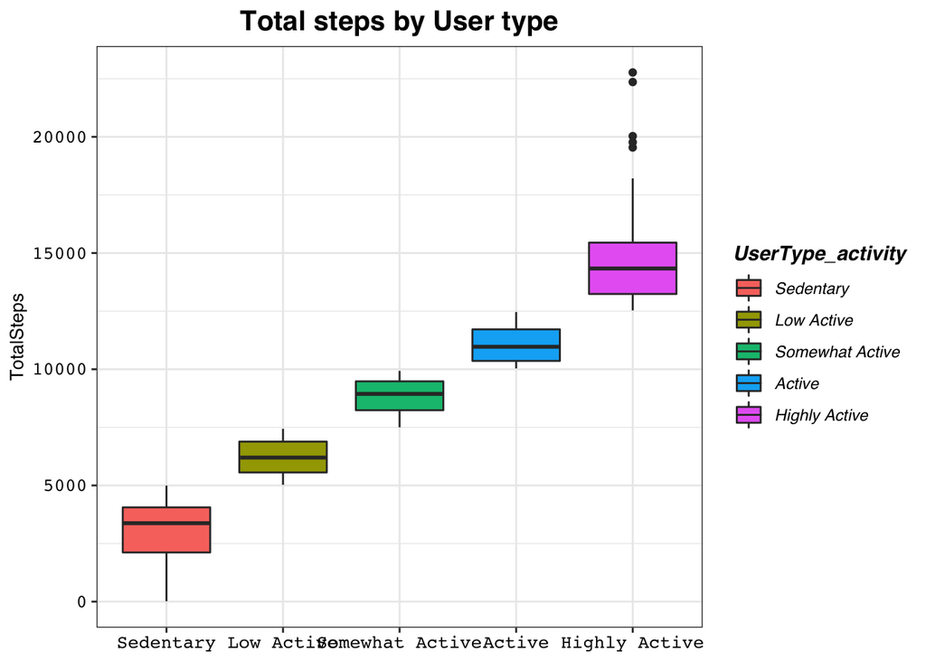

```r
#Viz 4
ggplot(combined_sleep_daily_activity, aes(UserType_activity, TotalSteps, fill=UserType_activity)) +
  geom_boxplot() +
  theme(legend.position="none") +
  labs(title="Total steps by User type", x=NULL) +
  theme(legend.position="none", text = element_text(size = 20),plot.title = element_text(hjust = 0.5)) + theme_bw() + mytheme +theme(plot.title = element_text(hjust = 0.5))
```

*Plot user type activity distribution:*

```r
#counting the numbers of each type of user and save it in a new table
freq_user_type_activity = combined_sleep_daily_activity %>%
  group_by(UserType_activity) %>%
  count() %>%
  ungroup()%>%
  arrange(desc(UserType_activity)) %>%
  mutate(percentage = round(n/sum(n),4)*100,
         lab.pos = cumsum(percentage)-.5*percentage)

freq_user_type_activity
```

```
## # A tibble: 5 x 4
##   UserType_activity     n percentage lab.pos
##   <fct>             <int>      <dbl>   <dbl>
## 1 Highly Active        65       15.7    7.87
## 2 Active              102       24.7   28.1
## 3 Somewhat Active      78       18.9   49.9
## 4 Low Active           72       17.4   68.0
## 5 Sedentary            96       23.2   88.4
```

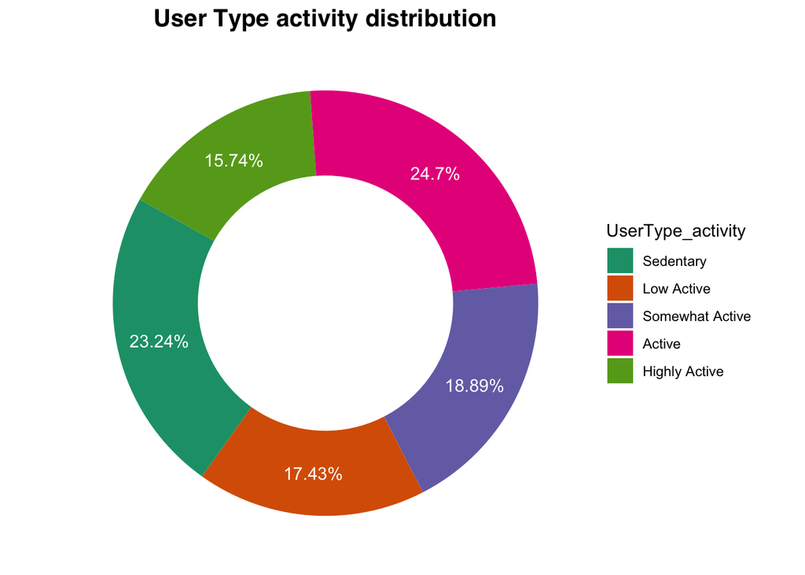

```r
# Viz 5 User type activity distribution
ggplot(data = freq_user_type_activity,
       aes(x = 2, y = percentage, fill = UserType_activity))+
  geom_bar(stat = "identity")+
  coord_polar("y", start = 200) +
  geom_text(aes(y = lab.pos, label = paste(percentage,"%", sep = "")), col = "white") +
  theme_void() +
  scale_fill_brewer(palette = "Dark2")+
  xlim(.2,2.5) +
  labs(title="User Type activity distribution") +theme(plot.title = element_text(family = "Helvetica", face = "bold", size = (15), hjust = 0.5))
```

*Plot user type BMI distribution:*

```r
#counting the numbers of each type of user and save it in a new table
freq_user_type_BMI = weight_log %>%
  group_by(UserType_BMI) %>%
  count() %>%
  ungroup()%>%
  arrange(desc(UserType_BMI)) %>%
  mutate(percentage = round(n/sum(n),4)*100,
         lab.pos = cumsum(percentage)-.5*percentage)

freq_user_type_BMI
```

```
## # A tibble: 3 x 4
##   UserType_BMI       n percentage lab.pos
##   <fct>          <int>      <dbl>   <dbl>
## 1 Obese              1       1.49   0.745
## 2 Overweight        32      47.8   25.4
## 3 Healthy weight    34      50.7   74.6
```

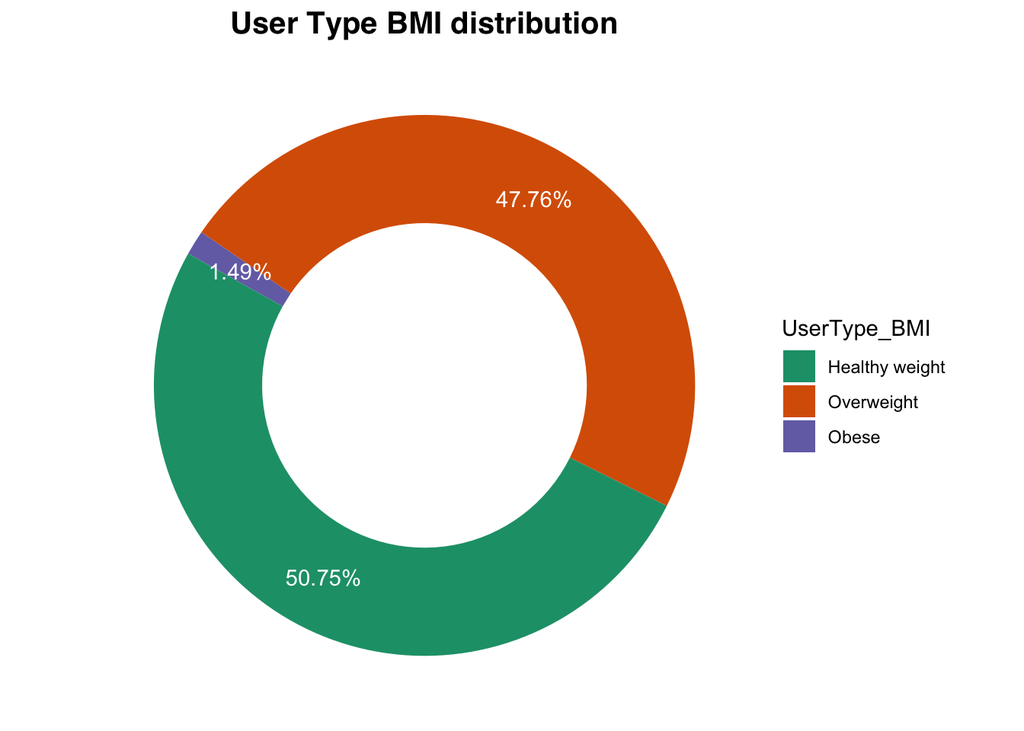

```r
# Viz 6 user type BMI distribution
ggplot(data = freq_user_type_BMI,
       aes(x = 2, y = percentage, fill = UserType_BMI))+
  geom_bar(stat = "identity")+
  coord_polar("y", start = 200) +
  geom_text(aes(y = lab.pos, label = paste(percentage,"%", sep = "")), col = "white") +
  theme_void() +
  scale_fill_brewer(palette = "Dark2")+
  xlim(.2,2.5) +
  labs(title="User Type BMI distribution") +theme(plot.title = element_text(family = "Helvetica", face = "bold", size = (15), hjust = 0.5))
```

*Plot user type sleep distribution:*

```r
#counting the numbers of each type of user by sleep time and save it in a new table
freq_user_type_sleep = combined_sleep_daily_activity %>%
  group_by(UserType_sleep) %>%
  count() %>%
  ungroup()%>%
  arrange(desc(UserType_sleep)) %>%
  mutate(percentage = round(n/sum(n),4)*100,
         lab.pos = cumsum(percentage)-.5*percentage)

freq_user_type_sleep
```

```
## # A tibble: 3 x 4
##   UserType_sleep     n percentage lab.pos
##   <fct>          <int>      <dbl>   <dbl>
## 1 Over sleep       115       27.8    13.9
## 2 Normal sleep     116       28.1    41.9
## 3 Under sleep      182       44.1    78.0
```

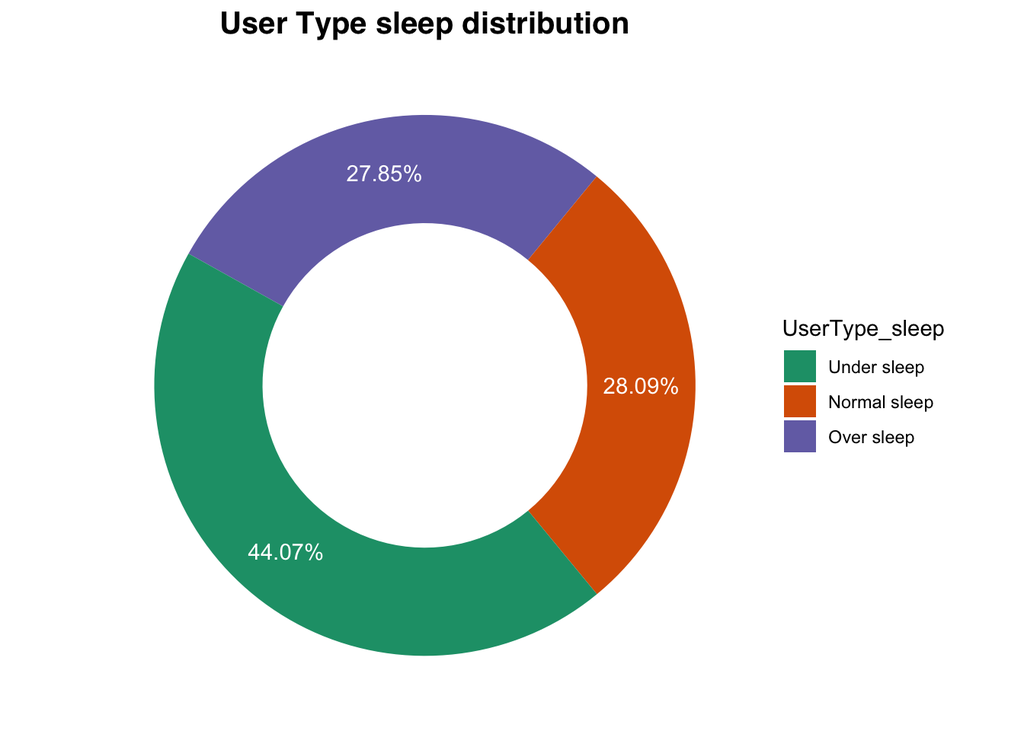

```r
# Viz 7 User type sleep distribution
ggplot(data = freq_user_type_sleep,
       aes(x = 2, y = percentage, fill = UserType_sleep))+
  geom_bar(stat = "identity")+
  coord_polar("y", start = 200) +
  geom_text(aes(y = lab.pos, label = paste(percentage,"%", sep = "")), col = "white") +
  theme_void() +
  scale_fill_brewer(palette = "Dark2")+
  xlim(.2,2.5) +
  labs(title="User Type sleep distribution") +theme(plot.title = element_text(family = "Helvetica", face = "bold", size = (15), hjust = 0.5))
```

*Plot type of sleep for user type:*

```r
#count total observations by UserType_activity and 'UserType_sleep' and save it in a new table
freq_UserType_UserTypeSleep <- combined_sleep_daily_activity %>% count(UserType_activity, UserType_sleep)

freq_UserType_UserTypeSleep
```

```
##    UserType_activity UserType_sleep  n
## 1          Sedentary    Under sleep 30
## 2          Sedentary   Normal sleep 23
## 3          Sedentary     Over sleep 43
## 4         Low Active    Under sleep 30
## 5         Low Active   Normal sleep 20
## 6         Low Active     Over sleep 22
## 7    Somewhat Active    Under sleep 35
## 8    Somewhat Active   Normal sleep 22
## 9    Somewhat Active     Over sleep 21
## 10            Active    Under sleep 46
## 11            Active   Normal sleep 40
## 12            Active     Over sleep 16
## 13     Highly Active    Under sleep 41
## 14     Highly Active   Normal sleep 11
## 15     Highly Active     Over sleep 13
```

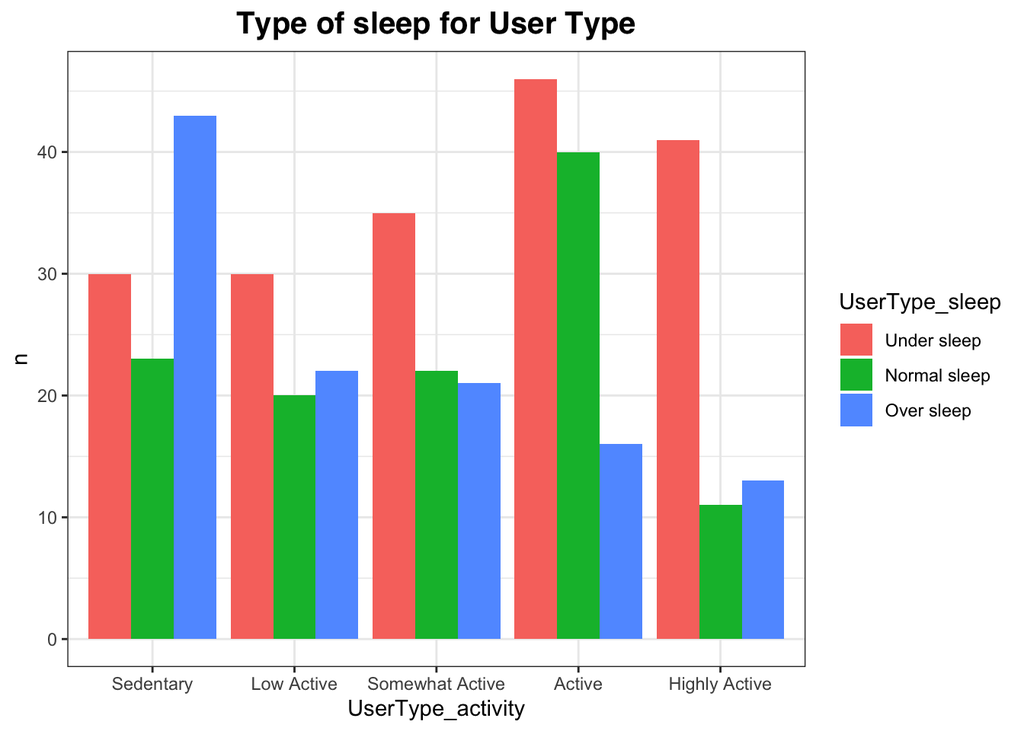

```r
# Viz 8 Type of sleep for user type
ggplot(freq_UserType_UserTypeSleep,
       aes(x = UserType_activity,
           y = n,
           fill = UserType_sleep)) +
  geom_bar(stat = "identity",
           position = "dodge")+ theme_bw() +
  labs(title="Type of sleep for User Type") +theme(plot.title = element_text(family = "Helvetica", face = "bold", size = (15), hjust = 0.5))
```

**6. Your top three recommendations based on your analysis (ACT)**

Bellabeat has already really advanced products and with the membership it is possibile to receive a fully personalized guidance on nutrition, activity, sleep, health and much more.

To further improve the quality of its service, Bellabeat can adopt an effective marketing strategy that concerns the upgrade of the UX design and a motivational approach.

In general the key solution that can help people being more active and determined in achieving their goal is showing them the improvement in their metrics and giving them rewards that will push them to improve more and more. For example, in the app there could be the possibility to set a new personal goal for the following week or month and, if the user succeeds, she would receive some stars or points. When the user has reached a certain number of stars or points, she can receive some discounts or bonus for either a sport activity or a Beallabeat product or service.

This kind of motivation can help the users loosing weight or keeping it under control, by looking at their daily calories consumption and at their weight and reducing their sedentary time so that they would be more tired in the evening and consequently sleep better.

Finally it could be also useful to have a forum where Bellabeat users can confront and support each other.